chris

[figure not shown]

# "Worth It" Wines

## Christopher Yue

1. Introduction
2. Data Wrangling
3. Exploratory Data Analysis
   - 3.1. Removing Duplicates
   - 3.2. Data Visualization
   - 3.3. Hypothesis Testing
   - 3.4. Defining the "Worth It" Score
   - 3.5. Finding the Most Worth It Wine Brands
4. Machine Learning
   - 4.1. Preparing the Data
   - 4.2. Training and Testing the Model
   - 4.3. Making Predictions
5. Conclusion
6. Resources

# 1. Introduction

The majority of us have been on a budget at one point in our lives (I still am), and let's face it: it's hard to live frugally and have a good time. Sometimes you just want to kick your feet up and relax with a nice, crisp glass of Chardonnay, but all you have are some Solo cups and a box of Franzia.  
In an attempt to put an end to this nationwide crisis, we are going for the top 25 wine brands that offer the best quality wine for the lowest prices. Using a dataset of 150,930 wine reviews from Kaggle (taken from Winemag.com), we will first analyze the relationship between the prices of a wines and the scores they received in review reviews. Then we will define what makes a wine "worth it" and find the top 25 most worth it wines so that you don't have to empty your pockets for a drink.

# 2. Data Wrangling

```python
from scipy import stats
from sklearn import linear_model
from sklearn import model_selection
import pandas as pd
import numpy as np
import matplotlib.pyplot as plt
import seaborn as sns
import statsmodels.formula.api as sm
%config InlineBackend.figure_format = 'retina'
%matplotlib inline
```

In this step, we are going to deal with the wine reviews that contain missing values. Often times, the easiest way to do so is to use the dropna() function on a pandas DataFrame (which is what the data is stored in below). Other methods deal with imputing, which means to replace the missing values with some sort of average. We are just going to use dropna() for our purposes.

```python
table = pd.read_csv('winemag-data_first150k.csv')

# Drop unnecessary column
table.drop(['Unnamed: 0'], axis=1, inplace=True)

# Rearrange columns
table = table[['country', 'variety', 'description', 'province', 'region_1', 'region_2', 'winery',
               'designation', 'price', 'points']]

# Drop rows with missing entries
table = table.dropna()
table
```

|  | country | variety | description | province | region_1 | region_2 | winery | designation | price | points |
| --- | --- | --- | --- | --- | --- | --- | --- | --- | --- | --- |
| 0 | US | Cabernet Sauvignon | This tremendous 100% varietal wine hails from ... | California | Napa Valley | Napa | Heitz | Martha's Vineyard | 235.0 | 96 |
| 2 | US | Sauvignon Blanc | Mac Watson honors the memory of a wine once ma... | California | Knights Valley | Sonoma | Macauley | Special Selected Late Harvest | 90.0 | 96 |
| 3 | US | Pinot Noir | This spent 20 months in 30% new French oak, an... | Oregon | Willamette Valley | Willamette Valley | Ponzi | Reserve | 65.0 | 96 |
| 8 | US | Pinot Noir | This re-named vineyard was formerly bottled as... | Oregon | Chehalem Mountains | Willamette Valley | Bergström | Silice | 65.0 | 95 |
| 9 | US | Pinot Noir | The producer sources from two blocks of the vi... | California | Sonoma Coast | Sonoma | Blue Farm | Gap's Crown Vineyard | 60.0 | 95 |
| 11 | US | Pinot Noir | From 18-year-old vines, this supple well-balan... | Oregon | Ribbon Ridge | Willamette Valley | Patricia Green Cellars | Estate Vineyard Wadensvil Block | 48.0 | 95 |
| 12 | US | Pinot Noir | A standout even in this terrific lineup of 201... | Oregon | Dundee Hills | Willamette Valley | Patricia Green Cellars | Weber Vineyard | 48.0 | 95 |
| 14 | US | Pinot Noir | With its sophisticated mix of mineral, acid an... | Oregon | Dundee Hills | Willamette Valley | Domaine Serene | Grace Vineyard | 185.0 | 95 |
| 15 | US | Chardonnay | First made in 2006, this succulent luscious Ch... | Oregon | Willamette Valley | Willamette Valley | Bergström | Sigrid | 90.0 | 95 |
| 16 | US | Cabernet Sauvignon | This blockbuster, powerhouse of a wine suggest... | California | Diamond Mountain District | Napa | Hall | Rainin Vineyard | 325.0 | 95 |
| 19 | US | Pinot Noir | This fresh and lively medium-bodied wine is be... | California | Sonoma Coast | Sonoma | Gary Farrell | Gap's Crown Vineyard | 75.0 | 95 |
| 20 | US | Rosé | Heitz has made this stellar rosé from the rare... | California | Napa Valley | Napa | Heitz | Grignolino | 24.0 | 95 |
| 23 | US | Chardonnay | The apogee of this ambitious winery's white wi... | California | Edna Valley | Central Coast | Center of Effort | Giallo Solare | 60.0 | 95 |
| 24 | US | Pinot Noir | San Jose-based producer Adam Comartin heads 1,... | California | Santa Cruz Mountains | Central Coast | Comartin | R-Bar-R Ranch | 45.0 | 95 |
| 27 | US | Pinot Noir | Focused and dense, this intense wine captures ... | Oregon | Willamette Valley | Willamette Valley | Ponzi | Abetina | 105.0 | 94 |
| 28 | US | Pinot Noir | Cranberry, baked rhubarb, anise and crushed sl... | California | Santa Lucia Highlands | Central Coast | Roar | Garys' Vineyard | 60.0 | 94 |
| 29 | US | Syrah | This standout Rocks District wine brings earth... | Washington | Walla Walla Valley (WA) | Columbia Valley | Saviah | The Funk Estate | 60.0 | 94 |
| 31 | US | Chardonnay | Steely and perfumed, this wine sees only 20% n... | California | Russian River Valley | Sonoma | Zepaltas | Babushka | 37.0 | 90 |
| 34 | US | Chardonnay | The aromas entice with notes of wet stone, hon... | Washington | Columbia Valley (WA) | Columbia Valley | Buty | Conner Lee Vineyard | 42.0 | 90 |
| 47 | US | Cabernet Sauvignon | Blended with 9% Malbec, 9% Cabernet Franc and ... | California | Mount Veeder | Napa | Brandlin | Estate Grown | 60.0 | 90 |
| 55 | US | Cabernet Sauvignon | A blend of Cabernet from Grand Ciel (31%), Cie... | Washington | Red Mountain | Columbia Valley | DeLille | Four Flags | 69.0 | 90 |
| 57 | US | Riesling | While exuberantly fruity, almost tropical on t... | New York | Finger Lakes | Finger Lakes | Dr. Konstantin Frank | Reserve | 25.0 | 90 |
| 58 | US | Cabernet Sauvignon-Syrah | Cabernet makes up just over half of this blend... | Washington | Columbia Valley (WA) | Columbia Valley | Efeste | Final Final | 30.0 | 90 |
| 65 | US | Syrah | Fresh boysenberries and a blueberry sorbet cha... | California | Santa Clara Valley | Central Coast | Jason-Stephens | Estate Select | 36.0 | 91 |
| 67 | US | Cabernet Sauvignon | From the producer's monumental Atlas Peak vine... | California | Napa Valley | Napa | Michael Mondavi Family Estate | Animo | 85.0 | 91 |
| 68 | US | Pinot Noir | Big, bold, dark and chewy, this builds upon su... | Oregon | Eola-Amity Hills | Willamette Valley | Panther Creek | Schindler Vineyard | 50.0 | 91 |
| 69 | US | Cabernet Sauvignon | A juiciness of cherry and vanilla spark the op... | California | Rutherford | Napa | Provenance Vineyards | Barrel Select | 60.0 | 91 |
| 70 | US | Cabernet Sauvignon | Sweetened tannins highlight a depth of chocola... | California | St. Helena | Napa | Raymond | District Collection | 85.0 | 91 |
| 75 | US | Pinot Noir | An elegant blend from different estate vineyar... | Oregon | Willamette Valley | Willamette Valley | Archery Summit | Premier Cuvée | 54.0 | 91 |
| 77 | US | Sauvignon Blanc | Given four months in concrete egg, this is an ... | California | Napa Valley | Napa | B Cellars | Juliana Vineyard | 38.0 | 91 |
| ... | ... | ... | ... | ... | ... | ... | ... | ... | ... | ... |
| 150751 | US | Zinfandel | Plummy, ripe, beginning to oxidize. Ready to d... | California | Dry Creek Valley | Sonoma | Meeker | Gold Leaf Cuvee | 18.0 | 82 |
| 150753 | US | Zinfandel | Simple and fruity and forward, though still un... | California | Sonoma County | Sonoma | Alexander Valley Vineyards | Sin Zin | 18.0 | 82 |
| 150755 | US | Zinfandel | Dark, brick colored wine, heavily oxidized, wi... | California | California | California Other | Maison Basque | Black Zinfandel | 24.0 | 82 |
| 150757 | US | Zinfandel | Full blueberry and blackberry aromas can't ove... | California | Amador County | Sierra Foothills | Renwood | Grandmére | 25.0 | 81 |
| 150758 | US | Vidal Blanc | The more I taste Vidal, the more I find it an ... | New York | Finger Lakes | Finger Lakes | Wagner | Ice Wine | 18.0 | 81 |
| 150762 | US | Cabernet Sauvignon | This wine is still young and precocious, but d... | California | Napa Valley | Napa | Beringer | Private Reserve | 100.0 | 95 |
| 150764 | US | Pinot Noir | Specially selected lots account for this top-o... | California | Carneros | Napa-Sonoma | Schug | Heritage Reserve | 30.0 | 93 |
| 150769 | US | Merlot | Dark, oaky, and fine in every respect. Sonoma ... | California | Sonoma Valley | Sonoma | Kenwood | Massara Vineyard | 25.0 | 92 |
| 150774 | US | Chardonnay | A very distinctive Chard—full of character and... | California | Russian River Valley | Sonoma | Fritz | Shop Block Vineyard Dutton Ranch | 30.0 | 91 |
| 150787 | US | Pinot Noir | This wine become pretty pricey but that's beca... | California | Sonoma County | Sonoma | Iron Horse | Thomas Road Vineyard | 50.0 | 90 |
| 150788 | US | Chardonnay | This Chard has always been dependably rich, an... | California | Santa Maria Valley | Central Coast | Byron | Byron Vineyard | 32.0 | 90 |
| 150790 | US | Bordeaux-style Red Blend | Always a bit herbaceous, this year the underly... | California | Sonoma County | Sonoma | Dry Creek Vineyard | Meritage | 28.0 | 90 |
| 150792 | US | Chardonnay | Strong , complex aromas, with notes of tropica... | California | Russian River Valley | Sonoma | Fritz | Ruxton Vineyard | 27.0 | 89 |
| 150794 | US | Zinfandel | Spicy black fruit, with bell pepper, black pep... | California | Napa Valley | Napa | Green & Red | Chiles Mill Vineyard | 22.0 | 89 |
| 150796 | US | Bordeaux-style Red Blend | Made largely of Cabernet Franc, this wine has ... | California | Santa Barbara County | Central Coast | Babcock | Fathom | 30.0 | 89 |
| 150803 | US | Pinot Noir | Here's a wine with great bones: nicely structu... | California | Napa Valley | Napa | Flora Springs | Lavender Hill Vineyard | 33.0 | 88 |
| 150807 | US | Chardonnay | Ripe, tropical fruit aromas mark this spicy, w... | California | Edna Valley | Central Coast | Talley | Oliver's Vineyard | 20.0 | 88 |
| 150812 | US | Zinfandel | Ripe, muscular wine, with a full throttle nose... | California | Napa Valley | Napa | Stonehedge | Reserve | 25.0 | 88 |
| 150827 | US | Cabernet Sauvignon | Opens with blackberries and spices; fruity, fo... | California | Dry Creek Valley | Sonoma | Dry Creek Vineyard | Epoch II Millenium Cuvée | 60.0 | 87 |
| 150831 | US | Chardonnay | A rich, creamy wine, loaded with personality. ... | California | Russian River Valley | Sonoma | Fritz | Dutton Vineyard | 22.0 | 87 |
| 150836 | US | Chardonnay | With this wine, Callaway takes a step away fro... | California | California | California Other | Callaway | Coastal | 10.0 | 86 |
| 150856 | US | Chardonnay | White Merlot? Why not? It's actually a deep ro... | California | California | California Other | Forest Glen | Forest Fire | 8.0 | 84 |
| 150861 | US | Chardonnay | From a dependable producer and a fine vintage ... | California | Sonoma County | Sonoma | Clos du Bois | Reserve | 16.0 | 84 |
| 150873 | US | Zinfandel | With a color akin to the soft pink of ripe pea... | California | Amador County | Sierra Foothills | Montevina | White | 7.0 | 83 |
| 150883 | US | Zinfandel | A coppery colored, off-dry-to-frankly-sweet wi... | California | California | California Other | Glen Ellen | Reserve White | 7.0 | 83 |
| 150889 | US | Pinot Noir | A bizarre style of wine. The aromas are Port-l... | California | Santa Ynez Valley | Central Coast | Lafond | Lafond Vineyard | 35.0 | 82 |
| 150892 | US | Merlot | A light, earthy wine, with violet, berry and t... | California | California | California Other | Callaway | Coastal | 10.0 | 82 |
| 150914 | US | White Riesling | Old-gold in color, and thick and syrupy. The a... | California | Anderson Valley | Mendocino/Lake Counties | Navarro | Late Harvest Cluster Select | 25.0 | 94 |
| 150915 | US | White Blend | Decades ago, Beringer’s then-winemaker Myron N... | California | North Coast | North Coast | Beringer | Nightingale | 30.0 | 93 |
| 150916 | US | Champagne Blend | An impressive wine that presents a full bouque... | California | Napa Valley | Napa | Schramsberg | J. Schram | 65.0 | 93 |

39241 rows × 10 columns

# 3. Exploratory Data Analysis

## 3.1. Removing Duplicates

```python
def check_for_dups(df):
    seen = set()
    dups = set()
    num_dups = 0
    for index, row in df.iterrows():
        # Check if already seen or not
        if row['description'] not in seen:
            seen.add(row['description'])
        else:
            dups.add(row['description'])
            num_dups += 1

    return dups, num_dups
```

Duplicate entries can really mess with data analysis, especially if there are a lot of a specific entry. For example, if we were to try to get the mean wine price from this dataset while the data included 1000 duplicate reviews of a $1,000 wine, the calculated mean would be much higher than it actually is. To see if duplicates are an issue, I want to check specifically the description column for duplicate entries, because two wines could coincidentally have other features that perfectly match (e.g. region, price, points). The description, however, must be unique to a review.

```python
dups, num_dups = check_for_dups(table)
# Truncated due to length
print('Some of the duplicates: ')
list(dups)[0:10]
```

```
Some of the duplicates:
```

```
['Sweet oak and lightly tropical fruit flavors characterize this young, tight, full-bodied Chardonnay. With another year or two in bottle, the fruit should emerge from behind the new oak flavors and enhance the overall balance. In the meanwhile, decanting is a good idea.',
 "A lovely dessert wine in almost every respect. It's crisp in acidity and has complex, somewhat oxidized or Madeira-like flavors of oranges, tapioca and vanilla. Could be a little more focused and intense, but very fine, although it calls for a certain appreciation of this oxidative quality.",
 "Dark, robust, dry, full bodied, tannic and acidic. That pretty much sums up this old-fashioned, young wine. It's a serious cellar candidate, stuffed with blackberry jam, leather and coffee flavors. Best after 2010 and for years beyond.",
 'The g3 name honors the third generation now moving into position at the winery. Dark and spicy, supple and firm, the wine shows depth and polish. Black fruits, earth, smoke, char, black olive and black tea all create a rather dark impression of a meaty wine ready for drinking with something substa…
 "This is an interesting and different wine. It's much lower in alcohol than most Cabs, but completely dry, with a tobacco and sage pull to the black currant flavors. The firm tannins suggest cellar possibilities.",
 'Combines power with delicacy to produce a savory, complex young Pinot Noir. Shows a silky texture and crisp coastal acidity, with potent flavors of ripe red cherries, Dr. Pepper cola, beef jerky and black pepper. Delicious and dry. Best now–2012.',
 "An Aussie-style blend of 78% Sauvignon Blanc and 22% Sémillon. It's been a real success for Cadaretta, and this is in the same mold as previous efforts. Tasted just prior to release, it was loaded with crisp, primary fruit flavors of green apple, melon and grapefruit. Nice texture, and just a hint…
 'This very rich, ripe and forward Pinot Noir can be opened now for its vast array of raspberries, cherries, cola, red licorice and smoky sandalwood. It grows more interesting as it warms in the glass, showing facets of pomegranates and violets. Will provide good drinking through 2014.',
 'This unusual blend of Chardonnay, Sauvignon Blanc and Viognier combines the attributes of crisp acidity and fruitiness. The result is a delicious, fine wine, rich in citrus, apricot and pear flavors that are a little sweet in white sugar.',
 'This wine shows those crisp, bright, mouthwatering Central Coast acids. They perk up the lime and tropical fruit flavors enhanced with a touch of vanilla and smoke from barrels. Finishes spicy and dry.']
```

There seem to be a lot of duplicate descriptions. Let's take a look at exactly how many of those reviews were duplicates.

```python
print('Number of duplicates: {}'.format(num_dups))
print('Percentage duplicates: {}%'.format(num_dups * 100 / len(table)))
```

```
Number of duplicates: 13819
Percentage duplicates: 35.21571825386713%
```

```python
table.drop_duplicates('description', inplace=True)
```

```python
dups, num_dups = check_for_dups(table)
print('Number of duplicates: {}'.format(num_dups))
```

```
Number of duplicates: 0
```

As you can see, approximately 35% of our original data consisted of duplicates. That's a lot of duplicates! We took care of this issue by simply dropping all of the rows that contain duplicate descriptions from our data. After running the code above, we are now duplicate-free.

```python
table
```

|  | country | variety | description | province | region_1 | region_2 | winery | designation | price | points |
| --- | --- | --- | --- | --- | --- | --- | --- | --- | --- | --- |
| 0 | US | Cabernet Sauvignon | This tremendous 100% varietal wine hails from ... | California | Napa Valley | Napa | Heitz | Martha's Vineyard | 235.0 | 96 |
| 2 | US | Sauvignon Blanc | Mac Watson honors the memory of a wine once ma... | California | Knights Valley | Sonoma | Macauley | Special Selected Late Harvest | 90.0 | 96 |
| 3 | US | Pinot Noir | This spent 20 months in 30% new French oak, an... | Oregon | Willamette Valley | Willamette Valley | Ponzi | Reserve | 65.0 | 96 |
| 8 | US | Pinot Noir | This re-named vineyard was formerly bottled as... | Oregon | Chehalem Mountains | Willamette Valley | Bergström | Silice | 65.0 | 95 |
| 9 | US | Pinot Noir | The producer sources from two blocks of the vi... | California | Sonoma Coast | Sonoma | Blue Farm | Gap's Crown Vineyard | 60.0 | 95 |
| 11 | US | Pinot Noir | From 18-year-old vines, this supple well-balan... | Oregon | Ribbon Ridge | Willamette Valley | Patricia Green Cellars | Estate Vineyard Wadensvil Block | 48.0 | 95 |
| 12 | US | Pinot Noir | A standout even in this terrific lineup of 201... | Oregon | Dundee Hills | Willamette Valley | Patricia Green Cellars | Weber Vineyard | 48.0 | 95 |
| 14 | US | Pinot Noir | With its sophisticated mix of mineral, acid an... | Oregon | Dundee Hills | Willamette Valley | Domaine Serene | Grace Vineyard | 185.0 | 95 |
| 15 | US | Chardonnay | First made in 2006, this succulent luscious Ch... | Oregon | Willamette Valley | Willamette Valley | Bergström | Sigrid | 90.0 | 95 |
| 16 | US | Cabernet Sauvignon | This blockbuster, powerhouse of a wine suggest... | California | Diamond Mountain District | Napa | Hall | Rainin Vineyard | 325.0 | 95 |
| 19 | US | Pinot Noir | This fresh and lively medium-bodied wine is be... | California | Sonoma Coast | Sonoma | Gary Farrell | Gap's Crown Vineyard | 75.0 | 95 |
| 20 | US | Rosé | Heitz has made this stellar rosé from the rare... | California | Napa Valley | Napa | Heitz | Grignolino | 24.0 | 95 |
| 23 | US | Chardonnay | The apogee of this ambitious winery's white wi... | California | Edna Valley | Central Coast | Center of Effort | Giallo Solare | 60.0 | 95 |
| 24 | US | Pinot Noir | San Jose-based producer Adam Comartin heads 1,... | California | Santa Cruz Mountains | Central Coast | Comartin | R-Bar-R Ranch | 45.0 | 95 |
| 27 | US | Pinot Noir | Focused and dense, this intense wine captures ... | Oregon | Willamette Valley | Willamette Valley | Ponzi | Abetina | 105.0 | 94 |
| 28 | US | Pinot Noir | Cranberry, baked rhubarb, anise and crushed sl... | California | Santa Lucia Highlands | Central Coast | Roar | Garys' Vineyard | 60.0 | 94 |
| 29 | US | Syrah | This standout Rocks District wine brings earth... | Washington | Walla Walla Valley (WA) | Columbia Valley | Saviah | The Funk Estate | 60.0 | 94 |
| 31 | US | Chardonnay | Steely and perfumed, this wine sees only 20% n... | California | Russian River Valley | Sonoma | Zepaltas | Babushka | 37.0 | 90 |
| 34 | US | Chardonnay | The aromas entice with notes of wet stone, hon... | Washington | Columbia Valley (WA) | Columbia Valley | Buty | Conner Lee Vineyard | 42.0 | 90 |
| 47 | US | Cabernet Sauvignon | Blended with 9% Malbec, 9% Cabernet Franc and ... | California | Mount Veeder | Napa | Brandlin | Estate Grown | 60.0 | 90 |
| 55 | US | Cabernet Sauvignon | A blend of Cabernet from Grand Ciel (31%), Cie... | Washington | Red Mountain | Columbia Valley | DeLille | Four Flags | 69.0 | 90 |
| 57 | US | Riesling | While exuberantly fruity, almost tropical on t... | New York | Finger Lakes | Finger Lakes | Dr. Konstantin Frank | Reserve | 25.0 | 90 |
| 58 | US | Cabernet Sauvignon-Syrah | Cabernet makes up just over half of this blend... | Washington | Columbia Valley (WA) | Columbia Valley | Efeste | Final Final | 30.0 | 90 |
| 65 | US | Syrah | Fresh boysenberries and a blueberry sorbet cha... | California | Santa Clara Valley | Central Coast | Jason-Stephens | Estate Select | 36.0 | 91 |
| 67 | US | Cabernet Sauvignon | From the producer's monumental Atlas Peak vine... | California | Napa Valley | Napa | Michael Mondavi Family Estate | Animo | 85.0 | 91 |
| 68 | US | Pinot Noir | Big, bold, dark and chewy, this builds upon su... | Oregon | Eola-Amity Hills | Willamette Valley | Panther Creek | Schindler Vineyard | 50.0 | 91 |
| 69 | US | Cabernet Sauvignon | A juiciness of cherry and vanilla spark the op... | California | Rutherford | Napa | Provenance Vineyards | Barrel Select | 60.0 | 91 |
| 70 | US | Cabernet Sauvignon | Sweetened tannins highlight a depth of chocola... | California | St. Helena | Napa | Raymond | District Collection | 85.0 | 91 |
| 75 | US | Pinot Noir | An elegant blend from different estate vineyar... | Oregon | Willamette Valley | Willamette Valley | Archery Summit | Premier Cuvée | 54.0 | 91 |
| 77 | US | Sauvignon Blanc | Given four months in concrete egg, this is an ... | California | Napa Valley | Napa | B Cellars | Juliana Vineyard | 38.0 | 91 |
| ... | ... | ... | ... | ... | ... | ... | ... | ... | ... | ... |
| 149204 | US | Merlot | Lovely aromas of kirsch and bacon are wrapped ... | New York | The Hamptons, Long Island | Long Island | Wölffer | Reserve | 22.0 | 87 |
| 149213 | US | Merlot | This is a plump, succulent Merlot that exhibit... | California | Monterey | Central Coast | Delicato | Monterey Vine Select San Bernabe Vineyard | 30.0 | 87 |
| 149214 | US | Cabernet Sauvignon | Lightly herbal, tight and dry, this is pure Ca... | Washington | Columbia Valley (WA) | Columbia Valley | Snoqualmie | Reserve | 23.0 | 87 |
| 149215 | US | Orange Muscat | Tastes beautifully rich in orange and vanilla ... | California | Amador County | Sierra Foothills | Sobon Estate | ReZerve | 15.0 | 87 |
| 149250 | US | Cabernet Sauvignon | This inaugural vintage from an ambitious winer... | California | Sonoma County | Sonoma | Roy J. Maier | Sonoma County Mountains | 60.0 | 87 |
| 149251 | US | Red Blend | The reserve comes from many of the same vineya... | Washington | Columbia Valley (WA) | Columbia Valley | Ryan Patrick | Reserve | 42.0 | 87 |
| 149255 | US | Sauvignon Blanc | Very fresh and crisp, with mixed flavors of me... | Washington | Red Mountain | Columbia Valley | Woodinville Wine Cellars | Artz Vineyard | 17.0 | 87 |
| 149257 | US | Cabernet Sauvignon | From a St. Helena vineyard on the Silverado Tr... | California | St. Helena | Napa | Château Boswell | Estate | 94.0 | 86 |
| 149259 | US | Zinfandel | This and the Gnarly Head bottling exemplify th... | California | Lodi | Central Valley | Clay Station | Old Vine | 12.0 | 86 |
| 149265 | US | Chardonnay | Showing the high, brisk acidity this region is... | California | Edna Valley | Central Coast | Mount Eden | Wolff Vineyard | 17.0 | 86 |
| 149269 | US | Zinfandel | Heady, briary aromas meld easily into flavors ... | California | Lodi | Central Valley | Gnarly Head | Old Vine | 11.0 | 86 |
| 149272 | US | Riesling | Medium body and good acidity set the tone, whi... | New York | Finger Lakes | Finger Lakes | Heron Hill | Icewine | 100.0 | 86 |
| 149341 | US | Pinot Noir | This tastes riper and hotter than the winery's... | California | Sta. Rita Hills | Central Coast | Brewer-Clifton | Melville | 64.0 | 86 |
| 149349 | US | Shiraz | The 2003 version wowed our tasting panel last ... | California | Monterey | Central Coast | Night Owl | San Bernabe Vineyard | 12.0 | 86 |
| 149357 | US | Riesling | Despite its “dry” label, this Riesling has a t... | New York | Finger Lakes | Finger Lakes | Chateau Lafayette Reneau | Dry | 15.0 | 86 |
| 149365 | US | Cabernet Franc | This wine has a stalky quality to the dark ber... | New York | Finger Lakes | Finger Lakes | Sheldrake Point | Barrel Reserve | 24.0 | 86 |
| 149367 | US | Riesling | Nice aromas of mint and golden raisin transfer... | New York | Finger Lakes | Finger Lakes | Heron Hill | Late Harvest | 36.0 | 86 |
| 149431 | US | Bordeaux-style Red Blend | Built for aging, this Merlot-dominant wine, wi... | New York | North Fork of Long Island | Long Island | Raphael | La Fontana | 20.0 | 86 |
| 149439 | US | Riesling | A dry, Alsatian-style Riesling with aromas of ... | New York | Finger Lakes | Finger Lakes | Heron Hill | Reserve | 25.0 | 85 |
| 149442 | US | Chardonnay | This Chard has a lot of lees and oak influence... | California | Anderson Valley | Mendocino/Lake Counties | Barnett | Savoy Vineyard | 35.0 | 85 |
| 149449 | US | Merlot | Brick red, with tight, grippy tannins, this me... | New York | North Fork of Long Island | Long Island | Osprey's Dominion | Reserve | 35.0 | 85 |
| 149459 | US | Meritage | Still a dark red, this wine is starting to sho... | New York | North Fork of Long Island | Long Island | Osprey's Dominion | Flight | 35.0 | 85 |
| 149521 | US | Sauvignon Blanc | A crisp, ripe wine, rich in spearmint, lemon a... | California | Napa Valley | Napa | Robert Pecota | L'Artiste | 15.0 | 85 |
| 149525 | US | Cabernet Sauvignon | Ripe, full-bodied and dry, this Cabernet has t... | California | Napa Valley | Napa | Merryvale | Starmont | 25.0 | 85 |
| 149533 | US | Pinot Noir | This particular wine is rather heavy and thick... | California | Santa Maria Valley | Central Coast | Waltzing Bear | Solomon Hills Vineyard | 45.0 | 85 |
| 149546 | US | Syrah | A dry, fruity red wine from a fine appellation... | California | Dry Creek Valley | Sonoma | Martin Ray | Angeline | 14.0 | 85 |
| 149613 | US | Mourvèdre | Drinks hot and thick in tannins, and despite s... | California | Contra Costa County | Central Coast | Jade Mountain | Evangelho Vineyard | 20.0 | 84 |
| 149629 | US | Red Blend | Half Merlot, with the rest Cabernet Sauvignon,... | New York | North Fork of Long Island | Long Island | Martha Clara | Five-O | 25.0 | 84 |
| 149630 | US | Merlot | Tastes kind of soft and thick in jammy cherry ... | California | Napa Valley | Napa | Pine Ridge | Crimson Creek | 27.0 | 84 |
| 149635 | US | Syrah-Grenache | A Syrah-Grenache blend that's dry and rustical... | California | Santa Barbara County | Central Coast | Casa Barranca | Bungalow Red | 15.0 | 84 |

25422 rows × 10 columns

## 3.2. Data Visualization

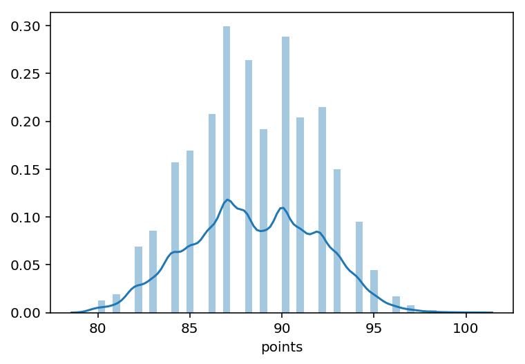

```python
sns.distplot(a=table['points'])
```

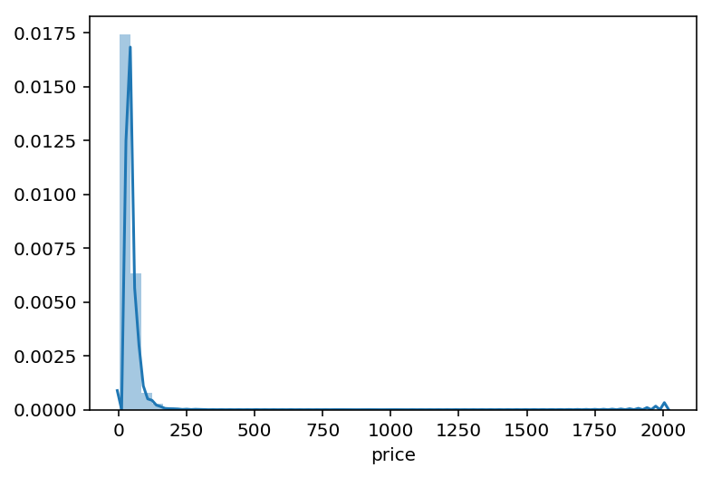

```python
sns.distplot(a=table['price'])
```

It looks like there are some outliers that are distorting the graph. We can remove them, normalize the data and then plot the graph again.

```python
table = table[np.abs(table['points'] - table['points'].mean()) <= (3*table['points'].std())]
table = table[np.abs(table['price'] - table['price'].mean()) <= (3*table['price'].std())]
```

```python
# Normalize the data
table['normalized_points'] = (table['points'] - table['points'].mean()) / table['points'].std()
table['normalized_price'] = (table['price'] - table['price'].mean()) / table['price'].std()
```

After removing outliers from and normalizing our data, the "points" data is a bit less positively skewed and the "price" data is much less skewed. Both graphs now look more like normal distributions (although the second one is still positively skewed). We see that the points mean is about 88 and the price mean is about $36.

```
The mean is at 88.40266070073109
```

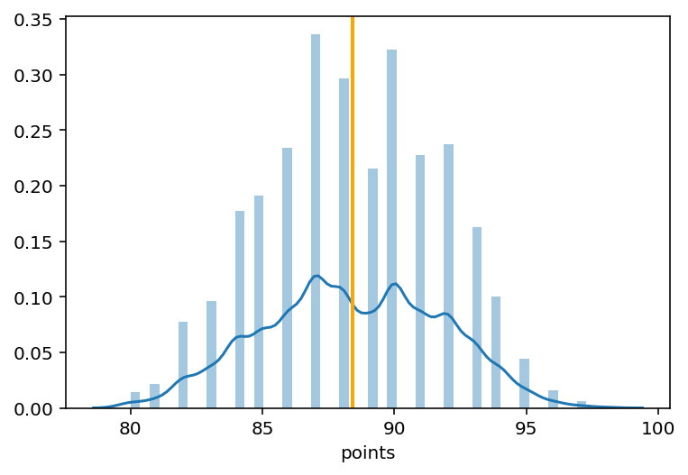

```python
sns.distplot(a=table['points'])
plt.axvline(table['points'].mean(), color="orange", linewidth=2)
print('The mean is at {}'.format(table['points'].mean()))
```

```
The mean is at 36.22791738244577
```

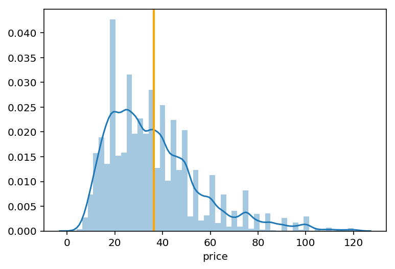

```python
sns.distplot(a=table['price'])
plt.axvline(table['price'].mean(), color="orange", linewidth=2)
print('The mean is at {}'.format(table['price'].mean()))
```

Taking another look at our data, I am highly suspicious of there being a correlation between the price of a wine and the number of points it receives. We can plot a graph of these two variables to get an idea of their relationship.

```python
sns.regplot(x=table['price'], y=table['points'], line_kws={'color': 'orange'})
```

[output not shown]